# BS 1515 Lecture 2: Linear Algebra

Sergey V. Popov

2026-09-21

# Last Time

- Sets and equations

Today: matrices

Why do we care about matrices

- Data is matrices
- Computers handle matrix operations very efficiently; machine learning and algorithmic trading rely heavily on linear algebra
- All smooth functions can be approximated by a linear (or quadratic) function locally

# Vectors

Vector space: space where elements can be added and multiplied by a *scalar* and results stay in the space.

Vector axioms:

- Associativity: $\mathbf{u}+(\mathbf{v}+\mathbf{w})=(\mathbf{u}+\mathbf{v})+\mathbf{w}$.
- Commutativity: $\mathbf{u}+\mathbf{v}=\mathbf{v}+\mathbf{u}$.
- There is a zero element: $\mathbf{u}+\mathbf{0}=\mathbf{u}$.
- $\forall \mathbf{v}$ there is an additive inverse $\mathbf{-v}$: $\mathbf{v}+(\mathbf{-v})=\mathbf{0}$.
- Scalar multiplication is associative: $a(b\mathbf{v})=(ab)\mathbf{v}$.
- Multiplying by 1 does not change anything: $1\mathbf{v}=\mathbf{v}$.
- Distributivity wrt vector addition: $a(\mathbf{v}+\mathbf{w})=a\mathbf{v}+a\mathbf{w}$.
- Distributivity wrt addition of scalars: $(a+b)\mathbf{v}=a\mathbf{v}+b\mathbf{v}$.

# Vectors

Prove: $\mathbf{R}$ is a vector space.

Prove: $0\mathbf{v}=\mathbf{0}$.

Prove: $s \mathbf{0}=\mathbf{0}$.

Prove: $-1\mathbf{v}=\mathbf{-v}$.

Prove: $s\mathbf{v}=\mathbf{0}$ means either $s=0$ or $\mathbf{v}=\mathbf{0}$.

# Linear Algebra

Most of the time, the vectors we work with have real number entries:

$$V=\begin{bmatrix}
v_1 \\
v_2 \\
\vdots \\
v_N
\end{bmatrix} \quad W=\begin{bmatrix}
w_1 & w_2 & \cdots & w_M
\end{bmatrix}$$

$V$ is a column vector of length $N$, $W$ is a row vector of length $M$.

# What can you do with vectors

Add them: if $V$ and $W$ are the same shape and size (say $N$-long row),

$$V+W=\begin{bmatrix}
v_1+w_1 & v_2+w_2 & \cdots & v_N+w_N
\end{bmatrix}$$

Multiply by a scalar: if $a\in \mathbb{R}$ and $V$ is a row vector of length $N$,
$$aV=\begin{bmatrix}
av_1 & av_2 & \cdots & av_N
\end{bmatrix}$$

Transpose: if $V$ is a row vector of length $N$,
$$V^T=\begin{bmatrix}
v_1 \\ v_2 \\ \vdots \\ v_N
\end{bmatrix}$$

Vector multiply: if $W$ is a row and $V$ is a column both length $N$:
$$WV=w_1v_1+w_2v_2+...+w_Nv_N.$$

# Matrices

$$A=\begin{bmatrix}
a_{11} & a_{12} & \cdots & a_{1N} \\
a_{21} & a_{22} & \cdots & a_{2N} \\
\vdots & \vdots & \ddots & \vdots\\
a_{M1} & a_{M2} & \cdots & a_{MN}
\end{bmatrix}$$

$A$ is an $M\times N$ matrix. Square matrices are $N\times N$.

- Row vectors are $1\times N$ matrices.
- Column vectors are $M\times 1$ matrices.
- Identity matrix $I_N$ is an $N\times N$ matrix with 1s on the diagonal and 0s outside:

$$I_N=\begin{bmatrix}
1 & 0 & \cdots & 0 \\
0 & 1 & \cdots & 0 \\
\vdots & \vdots & \ddots & \vdots\\
0 & 0 & \cdots & 1
\end{bmatrix}.$$

# Matrix as a Set of Vectors

A *linear combination* of vectors $v_1,\ldots,v_K$ is any $c_1v_1+c_2v_2+\ldots+c_Kv_K$ with scalars $c_1,\ldots,c_K$.

Let $A=\begin{bmatrix} a_{11} & a_{12} & \cdots & a_{1N} \\ a_{21} & a_{22} & \cdots & a_{2N} \\ \vdots & \vdots & \ddots & \vdots\\ a_{M1} & a_{M2} & \cdots & a_{MN} \end{bmatrix}$. Then:

- *column space*, or *range*, is everything that can be obtained as a linear combination of $\begin{bmatrix} a_{11} \\ a_{21} \\ \vdots \\ a_{M1} \end{bmatrix}$, $\begin{bmatrix} a_{12} \\ a_{22} \\ \vdots \\ a_{M2} \end{bmatrix}$, … $\begin{bmatrix} a_{1N} \\ a_{2N} \\ \vdots \\ a_{MN} \end{bmatrix}$.
- *row space* is everything you can get with linear combinations of rows.

# Matrix Multiplication

If $A$ is an $M\times N$ matrix,

- can multiply by an $N$-long column vector $v$ on the right:
  $$Av=\begin{bmatrix}
  a_{11} & a_{12} & \cdots & a_{1N} \\
  a_{21} & a_{22} & \cdots & a_{2N} \\
  \vdots & \vdots & \ddots & \vdots\\
  a_{M1} & a_{M2} & \cdots & a_{MN}
  \end{bmatrix}\begin{bmatrix}
  v_{1} \\
  v_{2} \\
  \vdots\\
  v_{N}
  \end{bmatrix}=\begin{bmatrix}
  a_{11}v_{1}+a_{12}v_2+...+a_{1N}v_N \\
  a_{21}v_{1}+a_{22}v_2+...+a_{2N}v_N \\
  \vdots\\
  a_{M1}v_{1}+a_{M2}v_2+...+a_{MN}v_N \\
  \end{bmatrix}.$$
- can multiply by a $M$-long row vector $w$ on the left:
  $$wA=\begin{bmatrix}
  w_{1} & w_{2} & \cdots & w_{M}
  \end{bmatrix}\begin{bmatrix}
  a_{11} & a_{12} & \cdots & a_{1N} \\
  a_{21} & a_{22} & \cdots & a_{2N} \\
  \vdots & \vdots & \ddots & \vdots\\
  a_{M1} & a_{M2} & \cdots & a_{MN}
  \end{bmatrix}=\begin{bmatrix}
  a_{11}w_{1}+a_{21}w_2+...+a_{M1}w_M \\
  a_{12}w_{1}+a_{22}w_2+...+a_{M2}w_M \\
  \vdots\\
  a_{1N}w_{1}+a_{2N}w_2+...+a_{MN}w_M \\
  \end{bmatrix}^T.$$
- Can multiply by $N\times P$ matrix on the right (getting a $M\times P$ matrix) or by $L \times M$ matrix on the left (getting a $L\times N$ matrix).

# Example

$$A=\begin{bmatrix}
2 & 1 & 3 & -1 \\
0 & 1 & -2 & 2 \\
-1 & -1 & -1 & -1
\end{bmatrix}.$$

- Multiply $A$ by $v=\begin{bmatrix} 2 \\ 1 \\ 3\\ 1 \end{bmatrix}$ on the right.
- Multiply $A$ by $w=\begin{bmatrix} 2 & 3 & 1 \end{bmatrix}$ on the left.
- Find $wAv$.

# Check yourself in R

```r
 A <- matrix(c(2,1,3,-1,0,1,-2,2,-1,-1,-1,-1), nrow = 3, ncol = 4, byrow = TRUE);
 v <- cbind(c(2,1,3,1));
 w <- c(2,3,1);
 printmatrix<-function(m){write.table(format(m, justify="right"),row.names=F, col.names=F, quote=F)};
 printmatrix(A%*%v)
```

```
## 13
## -3
## -7
```

```r
 printmatrix(w%*%A)
```

```
##  3  4 -1  3
```

```r
 printmatrix(w%*%A%*%v)
```

```
## 10
```

# Back to Range

Take $A$ - $M \times N$ matrix.

- Column space, or range, of $A$ is the set of vectors $A x$ for all $N\times 1$-dimenstional vectors $x$; this is a subspace of an $M$-dimensional vector space.
- Row space of $A$ is the set of vectors $wA$ for all $1\times M$-dimenstional vectors $w$; this is a subspace of an $N$-dimensional row vector space.
- Null space of $A$, or *kernel*, is the set of $N\times 1$-dimensional vectors $z$ such that $Az=0$. Observe that every row of $A$ multiplied by $z$ gives zero, so $z$ is orthogonal to everything in the row space.
- Left null space of $A$ is the set of $1\times M$-dimensional vectors $y$ such that $yA=0$. Observe that $y$ multiplied by every column of $A$ gives zero, so $y$ is orthogonal to everything in the column space.

# Systems of Linear Equations

Imagine we have a system of equations
$$2x+4y=5, 5x-2y=1.$$
Observe we can write it as
$$\begin{bmatrix}
2 & 4 \\
5 & -2
\end{bmatrix}\begin{bmatrix}
x \\
y
\end{bmatrix}=\begin{bmatrix}
5 \\
1
\end{bmatrix}.$$
If we had a matrix $B$ such that $B\begin{bmatrix} 2 & 4 \\ 5 & -2 \end{bmatrix}=I_2$, we could
$$\underbrace{B\begin{bmatrix}
2 & 4 \\
5 & -2
\end{bmatrix}\begin{bmatrix}
x \\
y
\end{bmatrix}}_{=I_2 \begin{bmatrix}
x \\
y
\end{bmatrix}=\begin{bmatrix}
x \\
y
\end{bmatrix}}=B\begin{bmatrix}
5 \\
1
\end{bmatrix}.$$
Can we find such a $B$? Maybe!

# Inverting Matrices

For a square $N \times N$ matrix $A$, a square matrix $B$ is an *inverse* if $BA=I_N$.

- Prove: if $B$ is the inverse of $A$, $A$ is the inverse of $B$.

Is it possible that there is no inverse? Yes. Consider $A=\begin{bmatrix} 0 & 0 \\ 0 & 0 \end{bmatrix}$ - no matter what matrix you multiply it by, you won’t get $I_2$.

- Prove: any matrix that has a zero row or a zero column cannot be *invertible*.
- Prove: any matrix that has two identical rows or columns cannot be invertible.
- Prove: any matrix that has two rows (or columns) such that one is a scalar multiple of the other cannot be invertible.
- Prove: any matrix that has a row (or column) which is the sum of two other rows (or columns) cannot be invertible.

Vectors are *linearly independent* if none of them is a linear combination of the others. *Rank* of the matrix is the maximum number of linearly independent rows (equivalently, columns). $N\times N$ matrices with rank $N$ are *full rank*. Only they are invertible.

# Gaussian Elimination

Imagine you want to invert matrix $A$. Write two matrices, $A$ and $I$, together
$$\begin{bmatrix}
a_{11} & a_{12} & a_{13} \\
a_{21} & a_{22} & a_{23} \\
a_{31} & a_{32} & a_{33}
\end{bmatrix}\begin{bmatrix}
1 & 0 & 0 \\
0 & 1 & 0 \\
0 & 0 & 1
\end{bmatrix}$$
Multiply by scalars, add subtract rows of both matrices at the same time to obtain an $I$ matrix on the left
$$\begin{bmatrix}
1 & \frac{a_{12}}{a_{11}} & \frac{a_{13}}{a_{11}} \\
a_{21} & a_{22} & a_{23} \\
a_{31} & a_{32} & a_{33}
\end{bmatrix}\begin{bmatrix}
\frac{1}{a_{11}} & 0 & 0 \\
0 & 1 & 0 \\
0 & 0 & 1
\end{bmatrix}$$
$$\begin{bmatrix}
1 & \frac{a_{12}}{a_{11}} & \frac{a_{13}}{a_{11}} \\
0 & a_{22}-\frac{a_{21}a_{12}}{a_{11}} & a_{23}-\frac{a_{21}
a_{13}}{a_{11}} \\
0 & a_{32}-\frac{a_{31}a_{12}}{a_{11}} & a_{33}-\frac{a_{31}
a_{13}}{a_{11}}
\end{bmatrix}\begin{bmatrix}
\frac{1}{a_{11}} & 0 & 0 \\
-\frac{a_{21}}{a_{11}} & 1 & 0 \\
-\frac{a_{31}}{a_{11}} & 0 & 1
\end{bmatrix}$$
Computers are very good at this.

# $2\times 2$ and $3\times3$ Matrices

Let $A=\begin{bmatrix} a & b \\ c & d \end{bmatrix}$. Then
$$A^{-1}=\frac{1}{ad-bc}\begin{bmatrix}
d & -b \\
-c & a
\end{bmatrix}.$$
Let $A=\begin{bmatrix} a & b & c \\ d & e & f \\ g & h & i \end{bmatrix}$. Then
$$A^{-1}=\frac{1}{aei+bfg+dhc-ceg-fha-bdi}\begin{bmatrix}
ei-fh & -(di-fg) & dh-eg \\
-(bi-ch) & ai-cg & -(ah-bg)\\
bf-ce & -(af-cd) & ae-bd
\end{bmatrix}^T.$$

Generically, depends on the notion of the *determinant*.

# Determinant

A *permutation* is a (finite) set of numbers where order matters. For a $N \times N$ matrix, take all permutations of $\{1,2,3,..N\}$, denote them $S_N$. Let $\operatorname{sgn}(\sigma)$ denote the sign of permutation $\sigma\in S_N$:

- $+1$ if you can go from $\{1,2,..N\}$ to $\sigma$ in even number of swaps of two entries,
- and $-1$ otherwise.

Then determinant of matrix $A$ is
$$\det A=\sum_{\sigma\in S_N}
\operatorname{sgn}(\sigma) a_{1,\sigma_1} \cdot a_{2,\sigma_2} \cdot
a_{3,\sigma_3} \cdot...\cdot a_{N,\sigma_N}.$$
For a $2\times 2$ matrix,
$$\det \begin{bmatrix}
a & b \\
c & d
\end{bmatrix} = ad-bc.$$

A matrix is invertible if and only if its determinant is not zero.

- Prove:
  $$\det \begin{bmatrix}
  a & b & c \\
  d & e & f \\
  g & h & i
  \end{bmatrix}= aei+bfg+dhc-ceg-fha-bdi.$$

# Quadratic Forms

Let $x$ be the column vector of $[x_1,x_2,..x_N]^T$. Consider a $N$-long row vector $w$. then
$$wx=w_1x_1+w_2x_2+..+w_Nx_N$$
is a *linear form*.

Consider a *symmetric* $N\times N$ matrix $A$. Then
$$x^TAx=a_{11}
x_1^2+2a_{12}x_1x_2+2a_{13}x_1x_3+...+a_{NN}x^2_N$$
is a *quadratic form*.

If your $A$ is not symmetric, then
$$x^TAx=a_{11}
x_1^2+(a_{21}+a_{12})x_1x_2+(a_{31}+a_{13})x_1x_3+...+a_{NN}x^2_N$$

# Positive Definite

Any $A$ such that for all $x$ $x^TAx>0$ is called *positive definite*.

To accomplish that:

- need to have $e_i^TAe_i>0$ so all diagonal elements positive
- need to have $(a e_i+be_j)^TA(ae_i+be_j)>0$ so all $2 \times 2$ *principal* submatrices (rows and columns $i,j$) are positive definite
- need to have $(a e_i+be_j+ce_k)^TA(ae_i+be_j+ce_k)>0$ so all $3 \times 3$ principal submatrices positive definite…

Determinants of these submatrices are called *principal minors*. The ones built from first $k$ rows and columns are *leading principal minors*.

For positive definiteness, need to check $det()>0$ of leading principal minors. For semidefiniteness, need to check $det()\geq 0$ for all principal minors, not just leading.

For negative definiteness, signs need to alternate, starting negative: $<0$ for $1\times1$, $>0$ for $2\times2$, $<0$ for $3\times3$, and so on.

Why?

# Matrix is a Transformation of a Vector

Consider matrix
$$A=\begin{bmatrix}
2 & 0 \\
0 & 1
\end{bmatrix}.$$
What does it do to a vector?

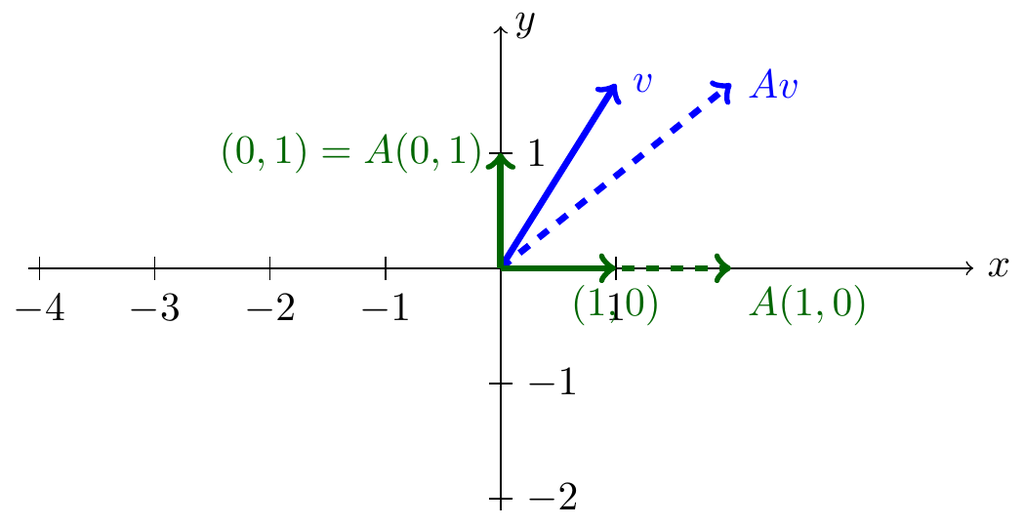

# Matrix is a Transformation of a Vector 2

Consider matrix
$$A=\begin{bmatrix}
0 & 1 \\
1 & 0
\end{bmatrix}.$$
What does it do to a vector?

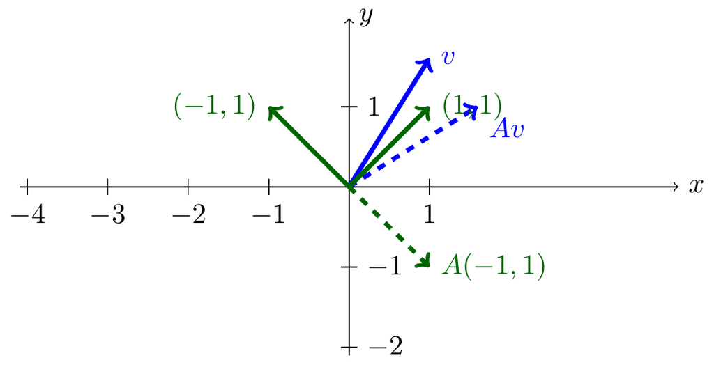

# Matrices Change Vectors

They

- stretch them
- change direction

A vector $v\not =0_N$ that does not change direction (going in the opposite direction is OK)if multiplied by $A$ is an *eigenvector* of the matrix $A$:
$$Av=\lambda v,$$
and $\lambda$ is the *eigenvalue*.

Claim: $det (A)=\lambda_1\lambda_2\lambda_3\cdot...\cdot \lambda_N$.

For a symmetric matrix: positive definite if and only if all eigenvalues are positive; negative definite if and only if all eigenvalues are negative. The minor test from the previous slide is a way to check this without computing the eigenvalues.

How to find $\lambda$: observe that $(A-\lambda I_N)v=0_N$ with $v\neq 0_N$, so $A-\lambda I_N$ is not invertible and $\det(A-\lambda I_N)=0$. This is a polynomial in $\lambda$.

# Example

Let $A=\begin{bmatrix} 2 & 3 \\ 1 & 2 \end{bmatrix}$

Then your characteristic equation is
$$\det \begin{bmatrix}
2-\lambda & 3 \\
1 & 2-\lambda
\end{bmatrix}=(2-\lambda)^2-3=0 \Rightarrow
\lambda_1=2-\sqrt{3},\lambda_2=2+\sqrt{3}.$$

Both eigenvalues are positive, but $A$ is not symmetric, so this tells us nothing about definiteness. In fact $x^TAx=2x_1^2+4x_1x_2+2x_2^2=2(x_1+x_2)^2$, which is $0$ at $x=(1,-1)$: $A$ is positive semidefinite, but not positive definite. For the eigenvalue $\lambda_2=2+\sqrt{3}$:
$$\begin{bmatrix}
2-\lambda_2 & 3\end{bmatrix}\begin{bmatrix}
1 \\ a\end{bmatrix}=-\sqrt{3}+3a=0\Rightarrow
a=\frac{\sqrt{3}}{3}.$$
So any vector proportional to $\begin{bmatrix} 1 \\ \sqrt{3}/3 \end{bmatrix}$ is an eigenvector.

# Normalizing an Eigenvector

To find a length $1$ eigenvector, (1) find the length of the one we have $\sqrt{\left(1^2+\left(\sqrt{3}/3\right)^2\right)}=\sqrt{12/9}$ and (2) then *normalize*:
$$\frac{1}{\sqrt{\frac{12}{9}}}\begin{bmatrix}
1 \\ \sqrt{3}/3 \end{bmatrix} \rightarrow \begin{bmatrix}
3/\sqrt{12} \\ \sqrt{3}/\sqrt{12}=\frac{1}{2}
\end{bmatrix}=:v_2.$$

The other eigenvector is found using the other eigenvalue:
$$\begin{bmatrix}
2-\lambda_1 & 3\end{bmatrix}\begin{bmatrix}
1 \\ a\end{bmatrix}=1\sqrt{3}+3a=0\Rightarrow
a=\frac{-\sqrt{3}}{3}.$$
So the eigenvector is $v_1:=\begin{bmatrix} 3/\sqrt{12} \\ -\sqrt{3}/\sqrt{12}=-\frac{1}{2}\end{bmatrix}.$ Observe that $v_1^Tv_2=\frac{9}{12}-\frac{1}{4}=1/2$ - they are not orthogonal, but if the matrix is symmetric, they must be.

- Verify: for $A=\begin{bmatrix} 2 & 3 \\ 3 & 2 \end{bmatrix}$ eigenvalues have opposite signs, and eigenvectors are orthogonal.

# Spectral Theorem and Matrix Inversion

If $A$ is symmetric, its eigenvalues are reals. $\Lambda$ is a diagonal matrix of real eigenvalues, and $Q$ is a matrix where column $i$ is the normalized eigenvector for eigenvalue $i$,
$$A=Q\Lambda Q^T.$$

This is a very strong result: in the coordinates $y=Q^Tx$, every quadratic form of a symmetric matrix is a sum of $N$ parabolas, $x^TAx=\lambda_1y_1^2+\ldots+\lambda_Ny_N^2$. If all of them are convex, the result must be convex; if all of them are concave, the result must be concave.

Observe that it is very easy to invert $\Lambda$: $\Lambda^{-1}$ is a diagonal matrix of $1/\lambda_i$. Observe also that $QQ^T=I$, so $Q$ is an inverse of $Q^T$, and vice versa. Therefore:
$$Q^TA=\underbrace{Q^TQ}_{I_N}\Lambda Q^T
\Rightarrow \Lambda^{-1} Q^T A = Q^T\Rightarrow \underbrace{Q
\Lambda^{-1} Q^T}_{A^{-1}} A =I_N.$$

# Learned Today

- Vectors and Matrices
- Vector Multiplication
- Eigenvalues and determinants: will be useful next lecture and in the future
- Matrix Transposition and Inversion: will be useful when you start data analysis

Next time: optimization!